# sandbox-01

Joshua Rosenberg

12/27/2017

# Sandbox - 03

### Background

This is a sandbox for exploring the data, in preparation for adding to the results section.

This document is organized around two sets of model specifications:

1. Fit using the R package `mclust`
2. Fit using the commerical software `MPlus`

Both are interfaced to through the `tidyLPA` package.

### Models that are specified

**mclust**

- All five variables w/ no prior (not evaluated)
- All five variables standardized w/ prior (not evaluated)

*MPlus*

- All five variables
- All five variables standardized
- All five variables w/ defaults
- All five variables standardized w/ defaults
- All five variables w/ strict defaults (not evaluated)
- All five variables standardized w/ strict defaults (not evaluated)

```r
library(tidyverse)
library(lmerTest)
library(lme4)
library(corrr)
library(jmRtools)
library(tidyLPA)
```

```r
esm <- read_csv("/Volumes/SCHMIDTLAB/PSE/data/STEM-IE/STEM-IE-esm.csv")
pre_survey_data_processed <- read_csv("/Volumes/SCHMIDTLAB/PSE/data/STEM-IE/STEM-IE-pre-survey.csv")
post_survey_data_partially_processed <- read_csv("/Volumes/SCHMIDTLAB/PSE/data/STEM-IE/STEM-IE-post-survey.csv")
video <- read_csv("/Volumes/SCHMIDTLAB/PSE/data/STEM-IE/STEM-IE-video.csv")
pqa <- read_csv("/Volumes/SCHMIDTLAB/PSE/data/STEM-IE/STEM-IE-pqa.csv")
attendance <- read_csv("/Volumes/SCHMIDTLAB/PSE/data/STEM-IE/STEM-IE-attendance.csv")
class_data <- read_csv("/Volumes/SCHMIDTLAB/PSE/data/STEM-IE/STEM-IE-class-video.csv")
demographics <- read_csv("/Volumes/SCHMIDTLAB/PSE/data/STEM-IE/STEM-IE-demographics.csv")
pm <- read_csv("/Volumes/SCHMIDTLAB/PSE/Data/STEM-IE/STEM-IE-program-match.csv")
```

```r
# save.image("~/desktop/sandbox-01.Rdata")
load("~/desktop/sandbox-01.Rdata")
```

```r
attendance <- rename(attendance, participant_ID = ParticipantID)
attendance <- mutate(attendance, prop_attend = DaysAttended / DaysScheduled,
                     participant_ID = as.integer(participant_ID))
attendance <- select(attendance, participant_ID, prop_attend)

demographics <- filter(demographics, participant_ID!= 7187)
demographics <- left_join(demographics, attendance)

esm$overall_engagement <- jmRtools::composite_mean_maker(esm, hard_working, concentrating, enjoy, interest)
```

```r
df <- left_join(esm, pre_survey_data_processed, by = "participant_ID") # df & post-survey
df <- left_join(df, video, by = c("program_ID", "response_date", "sociedad_class", "signal_number")) # df & video
df <- left_join(df, demographics, by = c("participant_ID", "program_ID")) # df and demographics
```

```r
pqa <- mutate(pqa,
              active = active_part_1 + active_part_2,
              ho_thinking = ho_thinking_1 + ho_thinking_2 + ho_thinking_3,
              belonging = belonging_1 + belonging_2,
              agency = agency_1 + agency_2 + agency_3 + agency_4,
              youth_development_overall = active_part_1 + active_part_2 + ho_thinking_1 + ho_thinking_2 + ho_thinking_3 + belonging_1 + belonging_2 + agency_1 + agency_2 + agency_3 + agency_4,
              making_observations = stem_sb_8,
              data_modeling = stem_sb_2 + stem_sb_3 + stem_sb_9,
              interpreting_communicating = stem_sb_6,
              generating_data = stem_sb_4,
              asking_questions = stem_sb_1,
              stem_sb = stem_sb_1 + stem_sb_2 + stem_sb_3 + stem_sb_4 + stem_sb_5 + stem_sb_6 + stem_sb_7 + stem_sb_8 + stem_sb_9)

# pqa <- rename(pqa, sixth_math_sociedad = sixth_math)
# pqa <- rename(pqa, seventh_math_sociedad = seventh_math)
# pqa <- rename(pqa, eighth_math_sociedad = eighth_math)
# pqa <- rename(pqa, dance_sociedad = dance)
# pqa <- rename(pqa, robotics_sociedad = robotics)

pqa$sociedad_class <- ifelse(pqa$eighth_math == 1, "8th Math",
                             ifelse(pqa$seventh_math == 1, "7th Math",
                                    ifelse(pqa$sixth_math == 1, "6th Math",
                                           ifelse(pqa$robotics == 1, "Robotics",
                                                  ifelse(pqa$dance == 1, "Dance", NA)))))

pqa <- rename(pqa,
              program_ID = SiteIDNumeric,
              response_date = resp_date,
              signal_number = signal)

pqa$program_ID <- as.character(pqa$program_ID)

df <- left_join(df, pqa, by = c("response_date", "program_ID", "signal_number", "sociedad_class"))
```

```r
df <- df %>%
    mutate(youth_activity_three = case_when(
        youth_activity_rc == "Creating Product" ~ "Creating Product",
        youth_activity_rc == "Basic Skills Activity" ~ "Basic Skills Activity",
        TRUE ~ "Other"
    ))

df$youth_activity_three <- fct_relevel(df$youth_activity_three,
                                       "Other")
```

```r
# <!-- Cognitive engagement As you were signaled, were you learning anything or getting better at something? -->
# <!-- Behavioral engagement    As you were signaled, how hard were you working? -->
# <!-- Affective engagement As you were signaled, did you enjoy what you are doing? -->
# <!-- Perceived challenge  As you were signaled, how challenging was the main activity? -->
# <!-- Perceived competence As you were signaled, were you good at the main activity? -->

library(jmRtools)

df <- df %>%
    mutate(dm_cog_eng = learning,
           dm_beh_eng = hard_working,
           dm_aff_eng = enjoy,
           dm_challenge = challenge,
           dm_competence = good_at) %>%
    rename(ssb_predict = stem_sb_1,
           ssb_model = stem_sb_2 ,
           ssb_analyze = stem_sb_3,
           ssb_measure = stem_sb_4,
           ssb_tools = stem_sb_5,
           ssb_precision = stem_sb_6,
           ssb_vocabulary = stem_sb_7,
           ssb_classification = stem_sb_8,
           ssb_symbols = stem_sb_9) %>%
    mutate(dm_ask = ssb_predict,
           dm_obs = ssb_classification,
           dm_gen = ifelse(ssb_measure == 1 | ssb_precision == 1, 1, 0),
           dm_mod = ifelse(ssb_model == 1 | ssb_analyze == 1, 1, 0),
           dm_com = ssb_symbols) %>%
    mutate(ov_cog_eng = (important + future_goals) / 2,
           ov_beh_eng = (hard_working + concentrating) / 2,
           ov_aff_eng = (enjoy + interest) / 2)
```

```r
out <- df %>%
    group_by(program_ID) %>%
    select(contains("ssb")) %>%
    summarize_all(sum, na.rm = T)

out1 <- pqa %>%
    select(contains("stem"), -sum_stem_sb, -stem_sb) %>%
    summarize_all(sum, na.rm = T) / 236

names(out1) <- df %>% select(contains("ssb")) %>% names()

pqa_out <- pqa %>%
    group_by(program_ID) %>%
    select(contains("stem"), -sum_stem_sb, -stem_sb) %>%
    summarize_all(sum, na.rm = T)

names(pqa_out) <- names(out)
```

# 1. mclust profiles

### 1A. All five - no prior

```r
df %>%
    select(dm_cog_eng, dm_beh_eng, dm_aff_eng, dm_challenge, dm_competence) %>%
    compare_solutions(contains("dm"))
```

### 1B. All five - prior

```r
df %>%
    select(dm_cog_eng, dm_beh_eng, dm_aff_eng, dm_challenge, dm_competence) %>%
    compare_solutions(contains("dm"), prior_control = T)
```

# Mplus

### 2A: All five variables w/ no prior

```r
out_df1 <- compare_solutions_mplus(df,
                                   dm_cog_eng, dm_beh_eng, dm_aff_eng, dm_challenge, dm_competence,
                                   n_processors = 8)
```

```
##   n_profiles             model_1  model_2             model_3
## 1          2           39916.157 38423.27 Convergence problem
## 2          3           39082.592 38049.88 Convergence problem
## 3          4           38616.439 37741.96 Convergence problem
## 4          5           38161.673 37490.66 Convergence problem
## 5          6            37718.88 37076.46 Convergence problem
## 6          7           37900.884 36874.38 Convergence problem
## 7          8           37443.138 37045.28 Convergence problem
## 8          9 Convergence problem 36561.57 Convergence problem
## 9         10 Convergence problem 36328.91 Convergence problem
##               model_4             model_5             model_6
## 1 Convergence problem Convergence problem Convergence problem
## 2 Convergence problem Convergence problem Convergence problem
## 3 Convergence problem Convergence problem Convergence problem
## 4 Convergence problem Convergence problem Convergence problem
## 5 Convergence problem Convergence problem Convergence problem
## 6 Convergence problem Convergence problem Convergence problem
## 7 Convergence problem Convergence problem Convergence problem
## 8 Convergence problem Convergence problem Convergence problem
## 9 Convergence problem Convergence problem Convergence problem
```

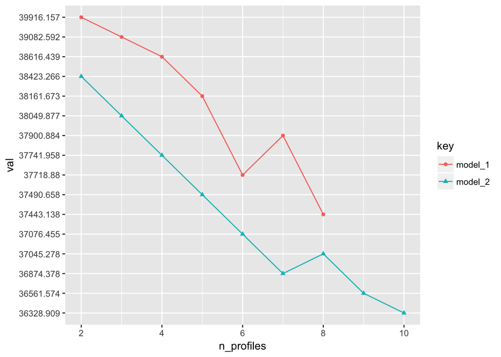

```r
# estimate_profiles_mplus(df,
#                         dm_cog_eng, dm_beh_eng, dm_aff_eng, dm_challenge, dm_competence, model = 2, n_profiles=2)
```

### 2B: All five variables standardized w/ no prior

```r
center_and_scale_vector <- function(x) {
    if (stats::sd(x, na.rm = TRUE) == 0) {
        x - mean(x, na.rm = TRUE)
    } else {
        (x - mean(x, na.rm = TRUE)) / stats::sd(x, na.rm = TRUE)
    }
}

df_ss <- df %>% select(dm_cog_eng, dm_beh_eng, dm_aff_eng, dm_challenge, dm_competence) %>% mutate_all(center_and_scale_vector)

out_df2 <- compare_solutions_mplus(df_ss, dm_cog_eng, dm_beh_eng, dm_aff_eng, dm_challenge, dm_competence, n_processors=8)
```

```
##   n_profiles             model_1  model_2             model_3
## 1          2           38639.754 37146.86 Convergence problem
## 2          3           37806.188 36773.47 Convergence problem
## 3          4           37340.035 36465.56 Convergence problem
## 4          5           36885.269 36214.25 Convergence problem
## 5          6           36442.477 35800.05 Convergence problem
## 6          7           36624.481 35597.97 Convergence problem
## 7          8           36166.735 35768.87 Convergence problem
## 8          9 Convergence problem 35285.17 Convergence problem
## 9         10 Convergence problem 35052.50 Convergence problem
##               model_4             model_5             model_6
## 1 Convergence problem Convergence problem Convergence problem
## 2 Convergence problem Convergence problem Convergence problem
## 3 Convergence problem Convergence problem Convergence problem
## 4 Convergence problem Convergence problem Convergence problem
## 5 Convergence problem Convergence problem Convergence problem
## 6 Convergence problem Convergence problem Convergence problem
## 7 Convergence problem Convergence problem Convergence problem
## 8 Convergence problem Convergence problem Convergence problem
## 9 Convergence problem Convergence problem Convergence problem
```

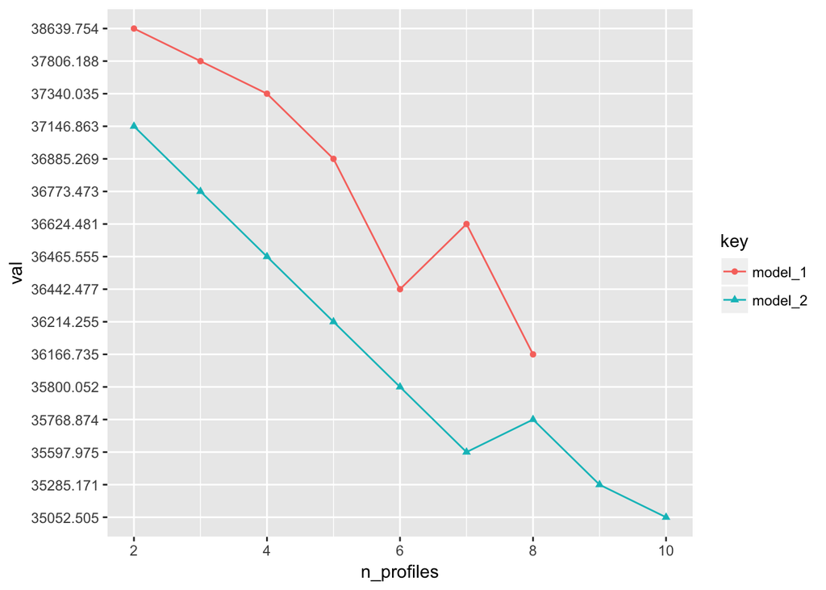

### 2C: All five variables w/ no prior w/ suggested settings

```r
out_df3 <- compare_solutions_mplus(df, dm_cog_eng, dm_beh_eng, dm_aff_eng, dm_challenge, dm_competence, st_iterations = 50, starts = c(500, 50))
```

```
##   n_profiles             model_1             model_2             model_3
## 1          2           39916.157           38423.266 Convergence problem
## 2          3           39082.592   LL not replicated Convergence problem
## 3          4 Convergence problem   LL not replicated Convergence problem
## 4          5 Convergence problem   LL not replicated Convergence problem
## 5          6 Convergence problem   LL not replicated Convergence problem
## 6          7 Convergence problem   LL not replicated Convergence problem
## 7          8 Convergence problem Convergence problem Convergence problem
## 8          9 Convergence problem Convergence problem Convergence problem
## 9         10 Convergence problem Convergence problem Convergence problem
##               model_4             model_5             model_6
## 1 Convergence problem Convergence problem Convergence problem
## 2 Convergence problem Convergence problem Convergence problem
## 3 Convergence problem Convergence problem Convergence problem
## 4 Convergence problem Convergence problem Convergence problem
## 5 Convergence problem Convergence problem Convergence problem
## 6 Convergence problem Convergence problem Convergence problem
## 7 Convergence problem Convergence problem Convergence problem
## 8 Convergence problem Convergence problem Convergence problem
## 9 Convergence problem Convergence problem Convergence problem
```

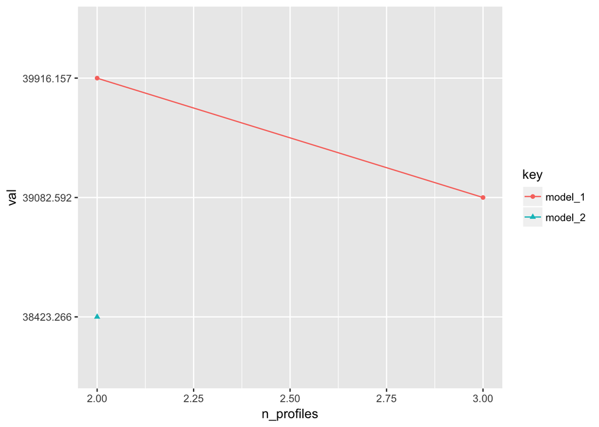

### 2D: All five variables standardized w/ no prior w/ suggested settings

```r
out_df4 <- compare_solutions_mplus(df_ss, dm_cog_eng, dm_beh_eng, dm_aff_eng, dm_challenge, dm_competence, st_iterations = 50, starts = c(500, 50))
```

```
##   n_profiles             model_1             model_2             model_3
## 1          2           38639.754           37146.863 Convergence problem
## 2          3           37806.188   LL not replicated Convergence problem
## 3          4 Convergence problem   LL not replicated Convergence problem
## 4          5 Convergence problem   LL not replicated Convergence problem
## 5          6 Convergence problem   LL not replicated Convergence problem
## 6          7 Convergence problem   LL not replicated Convergence problem
## 7          8 Convergence problem Convergence problem Convergence problem
## 8          9 Convergence problem Convergence problem Convergence problem
## 9         10 Convergence problem Convergence problem Convergence problem
##               model_4             model_5             model_6
## 1 Convergence problem Convergence problem Convergence problem
## 2 Convergence problem Convergence problem Convergence problem
## 3 Convergence problem Convergence problem Convergence problem
## 4 Convergence problem Convergence problem Convergence problem
## 5 Convergence problem Convergence problem Convergence problem
## 6 Convergence problem Convergence problem Convergence problem
## 7 Convergence problem Convergence problem Convergence problem
## 8 Convergence problem Convergence problem Convergence problem
## 9 Convergence problem Convergence problem Convergence problem
```

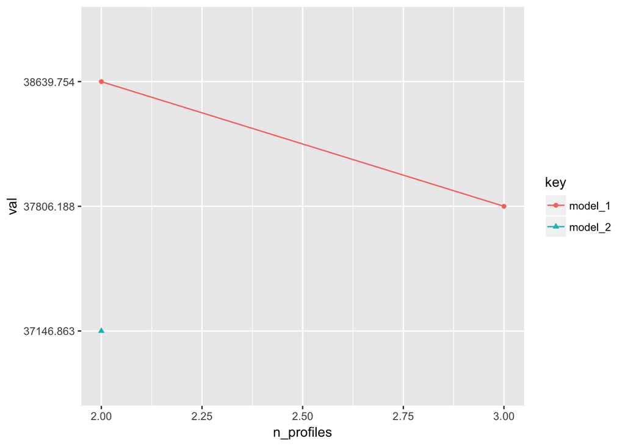

### 2E: All five variables w/ no prior w/ suggested settings and strict convergence

```r
out_df5 <- compare_solutions_mplus(df, dm_cog_eng, dm_beh_eng, dm_aff_eng, dm_challenge, dm_competence, st_iterations = 50, starts = c(500, 50), convergence_criterion=1E-7)
```

### 2F: All five variables standardized w/ no prior w/ suggested settings and strict convergence

```r
out_df6 <- compare_solutions_mplus(df_ss, dm_cog_eng, dm_beh_eng, dm_aff_eng, dm_challenge, dm_competence, st_iterations = 50, starts = c(500, 50),convergence_criterion= 1E-7)
```